# Preprocessing sample 3

## Alternative Normalization

```python
import rpy2
import logging
from rpy2.robjects import pandas2ri
```

import rpy2 import logging from rpy2.robjects import pandas2ri

```python
%load_ext rpy2.ipython
```

%load_ext rpy2.ipython

```python
rawMatrix = np.array( data.layers['raw_counts'].T.copy() )
genes_name = data.var_names
cells_info = data.obs[ ['batch','total_counts'] ].copy()
```

rawMatrix = np.array( data.layers['raw_counts'].T.copy() ) genes_name = data.var_names cells_info = data.obs[ ['batch','total_counts'] ].copy()

```python
%%R -i cells_info -i rawMatrix -i genes_name
library(scater)
cell_df <- DataFrame(data = cells_info)
colnames(rawMatrix) <- rownames(cell_df) #cell names
rownames(rawMatrix) <- genes_name #gene names
```

%%R -i cells_info -i rawMatrix -i genes_name library(scater) cell_df <- DataFrame(data = cells_info) colnames(rawMatrix) <- rownames(cell_df) #cell names rownames(rawMatrix) <- genes_name #gene names

[output not shown]

```python
%%R
library(sctransform)
library(future)
future::plan(strategy = 'multicore', workers = 4)
options(future.globals.maxSize = 1003 * 1024 ^ 3)
```

%%R library(sctransform) library(future) future::plan(strategy = 'multicore', workers = 4) options(future.globals.maxSize = 1003 * 1024 ^ 3)

```
R[write to console]:
```

```python
%%R
cell_df[1:5,]
```

%%R cell_df[1:5,]

```
DataFrame with 5 rows and 2 columns
                          data.batch data.total_counts
                            <factor>         <numeric>
CTGCCTACACACCGAC-Sample_1   Sample_1             17961
AGGCCGTCACTTACGA-Sample_1   Sample_1             18632
CAGCTGGAGCTCCCAG-Sample_1   Sample_1             19267
GCTTGAACATGCCCGA-Sample_1   Sample_1             19425
GCGAGAAGTATAGGGC-Sample_1   Sample_1             19384
```

```python
%%R
vst_out=vst( rawMatrix, cell_attr=cell_df, n_genes=5000,
            method = "poisson",
            #batch_var='data.batch',
            min_cells=10,
            return_corrected_umi=TRUE)
#correct
```

%%R vst_out=vst( rawMatrix, cell_attr=cell_df, n_genes=5000, method = "poisson", #batch_var='data.batch', min_cells=10, return_corrected_umi=TRUE) #correct

```
R[write to console]: Calculating cell attributes from input UMI matrix: log_umi

R[write to console]: Variance stabilizing transformation of count matrix of size 28510 by 6064

R[write to console]: Model formula is y ~ log_umi

R[write to console]: Get Negative Binomial regression parameters per gene

R[write to console]: Using 5000 genes, 6064 cells
```

```
R[write to console]: Found 111 outliers - those will be ignored in fitting/regularization step


R[write to console]: Second step: Get residuals using fitted parameters for 28510 genes
```

```
R[write to console]: Computing corrected count matrix for 28510 genes
```

```
R[write to console]: Calculating gene attributes

R[write to console]: Wall clock passed: Time difference of 3.817489 mins
```

```python
%%R -o new_matrix -o sct_genes -o all_genes -o corr_umi
new_matrix = vst_out$y
sct_genes = rownames(vst_out$model_pars)
all_genes = rownames(new_matrix)
corr_umi = as.matrix(vst_out$umi_corrected)
```

%%R -o new_matrix -o sct_genes -o all_genes -o corr_umi new_matrix = vst_out$y sct_genes = rownames(vst_out$model_pars) all_genes = rownames(new_matrix) corr_umi = as.matrix(vst_out$umi_corrected)

```python
sct_genes = np.array(sct_genes)
all_genes = np.array(all_genes)
```

sct_genes = np.array(sct_genes) all_genes = np.array(all_genes)

```python
data.var['highly_variable'] = [i in sct_genes for i in data.var_names]
data = data[:,all_genes].copy()
data.layers['all_norm_sct'] = np.transpose( new_matrix )
data.layers['corr_umi'] = np.transpose( corr_umi )
```

data.var['highly_variable'] = [i in sct_genes for i in data.var_names] data = data[:,all_genes].copy() data.layers['all_norm_sct'] = np.transpose( new_matrix ) data.layers['corr_umi'] = np.transpose( corr_umi )

```python
data.X = data.layers['all_norm_sct'].copy()
```

data.X = data.layers['all_norm_sct'].copy()

```python
sc.preprocessing.pca(data, svd_solver='arpack', random_state=12345)
```

sc.preprocessing.pca(data, svd_solver='arpack', random_state=12345)

```python
data
```

data

[output not shown]

```python
sc.plotting.pca_variance_ratio(data)
```

sc.plotting.pca_variance_ratio(data)

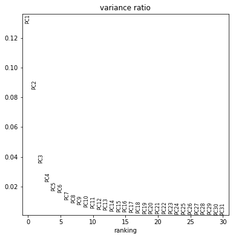

```python
plt.rcParams['figure.figsize'] = (6,6) #reduce figure size
sc.pl.pca(data, color=['batch','total_counts','SYCP1'])
```

plt.rcParams['figure.figsize'] = (6,6) #reduce figure size sc.pl.pca(data, color=['batch','total_counts','SYCP1'])

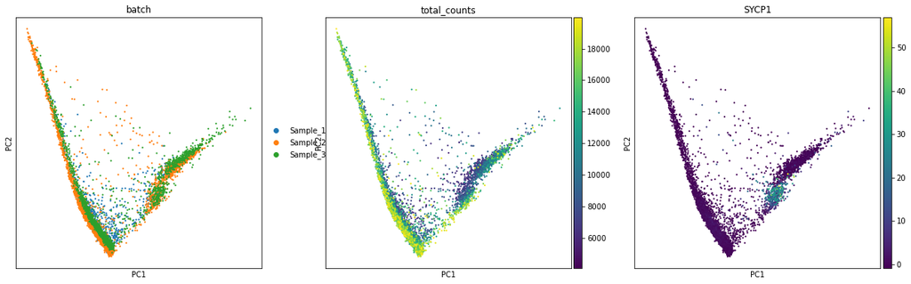

```python
import bbknn
bbknn.bbknn(data,  batch_key='batch')
```

import bbknn bbknn.bbknn(data, batch_key='batch')

```python
sc.tools.umap(data, random_state=1111, n_components=2)
```

sc.tools.umap(data, random_state=1111, n_components=2)

```python
sc.plotting.umap(data, color=['batch','n_genes_by_counts','total_counts','CFD'])
```

sc.plotting.umap(data, color=['batch','n_genes_by_counts','total_counts','CFD'])

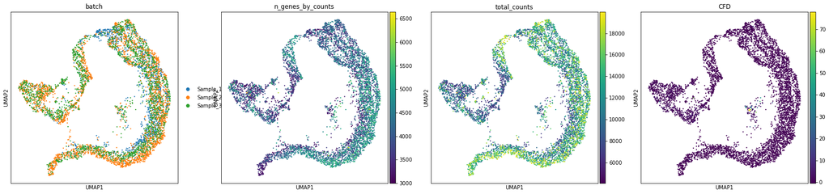